# Climate Report

Temperature and Precipitation 1960-2014

<5/10/19>

### Data

This is data from NOAA that is used to make maps that show air temp and precipitation values from 1960, 1986, and 2014.

### Temperature

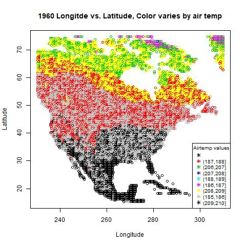

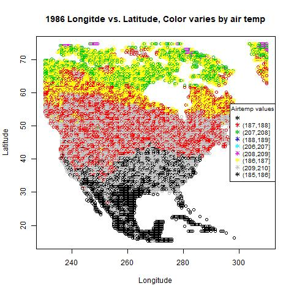

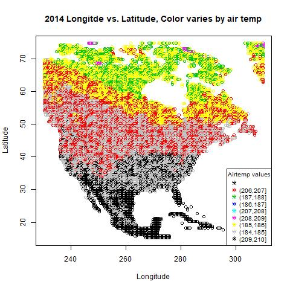

It seems that the really cold purple temperatures in the north dwindled, the colder (yellow/green) temperatures that were around the canadian/USA boarder seem to have crept farther down south as well. But it seems like the 2014 temp data matches the 1960 temp closer than the 1986 temp does.

### Precipitation

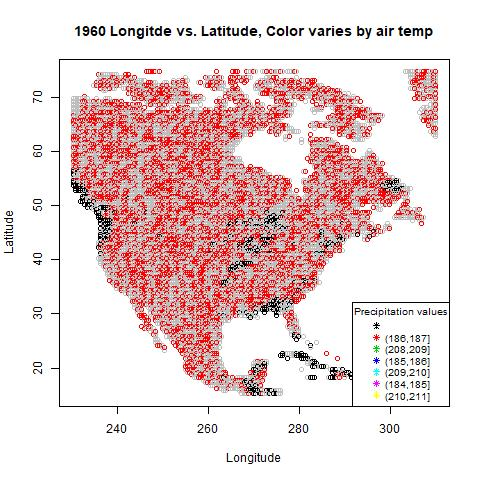

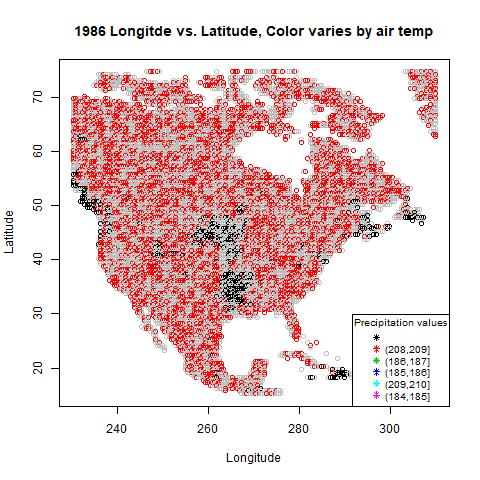

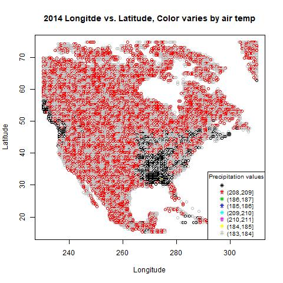

The patterns look reasonable here. The 2014 precipitation data looks like the central heavy precip values moved heavily and dramatically increased to the south east of the US. South Mexico’s precip values seemed to have dwindled a lot since 1960.

### Note:

It’s hard to really notice many long term trends based on only 3 figures. There did not seem to be a strong pattern established in either of the data sets. The cold temperatures near the north pole becoming less prevalent was however, something that was noticable.